# Effect of Fifa Player Ratings on Real Life Wages

Alan Qin

03/04/2020

# Project Introduction

# Fixing Data

```r
newData = as_tibble(data)
data1 = newData %>%
  dplyr::select(wage_eur, age, height_cm, weight_kg, overall,
         potential, value_eur, international_reputation,
         weak_foot, skill_moves, release_clause_eur, pace,
         shooting, passing, dribbling, defending, physic)
#data1[1] = log(data1[1])
dataOmit = na.omit(data1)
fifa_data = dataOmit
```

# Report 1

## Histogram for my X’s and Y’s

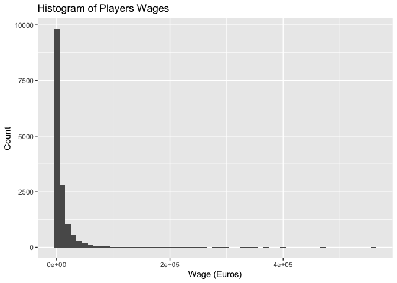

```r
ggplot(data = fifa_data, aes(x = wage_eur)) +
  geom_histogram(bins = 1000, binwidth = 10000) +
  ggtitle('Histogram of Players Wages') +
  labs(x = 'Wage (Euros)', y = "Count")
```

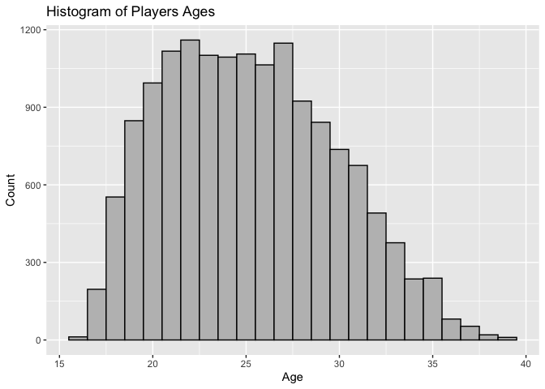

```r
ggplot(data = fifa_data, aes(x = age)) +
  geom_histogram(binwidth = 1, color = 'black', fill = 'gray') +
  ggtitle('Histogram of Players Ages') +
  labs(x = 'Age', y = "Count")
```

As we can see from this histogram, there are many players within the age range of 20-29 while there are few players younger than 18 and older than 35. There are the most players within the age range of 20-29 because that is their physical peak.

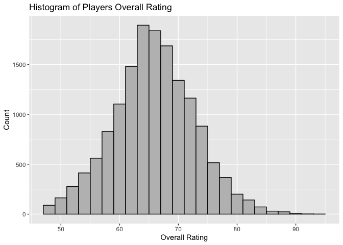

```r
ggplot(data = fifa_data, aes(x = overall)) +
  geom_histogram(binwidth = 2, color = 'black', fill = 'gray') +
  ggtitle('Histogram of Players Overall Rating') +
  labs(x = 'Overall Rating', y = "Count")
```

As we can see from this histogram, the mode of the overall rating of a player in FIFA 20 is around 65 points. The histogram also looks like it is normally distributed.

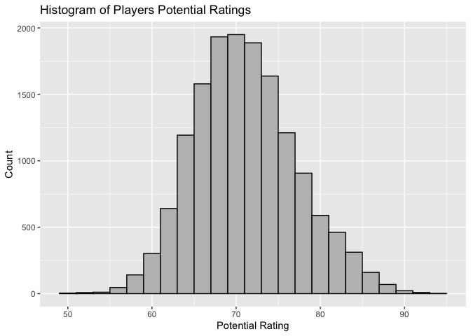

```r
ggplot(data = fifa_data, aes(x = potential)) +
  geom_histogram(binwidth = 2, color = 'black', fill = 'gray') +
  ggtitle('Histogram of Players Potential Ratings') +
  labs(x = 'Potential Rating', y = "Count")
```

Simliarly to the Overall Rating Histogram, the potential ratings of players are also normally distributed. However, the average potential rating of FIFA players increased to around 70 points instead of 65.

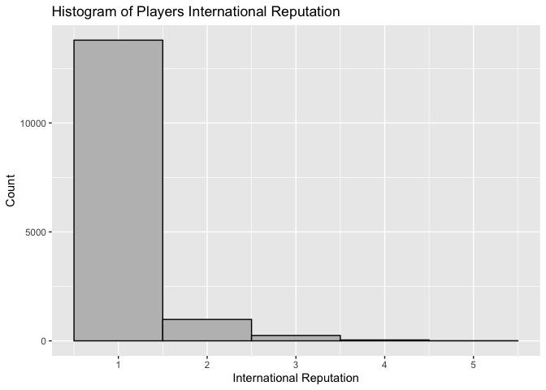

```r
ggplot(data = fifa_data, aes(x = international_reputation)) +
  geom_histogram(binwidth = 1, color = 'black', fill = 'gray') +
  ggtitle('Histogram of Players International Reputation') +
  labs(x = 'International Reputation', y = "Count")
```

This histogram shows that there are many players with an international reputation of 1 with less than 2000 players with a rating above. I think this is the case becuase international repuation is based off of how well the player plays for their national team. Since there are only so many spots on a national team it makes sense that the vast majority of players have an international reputation of 1.

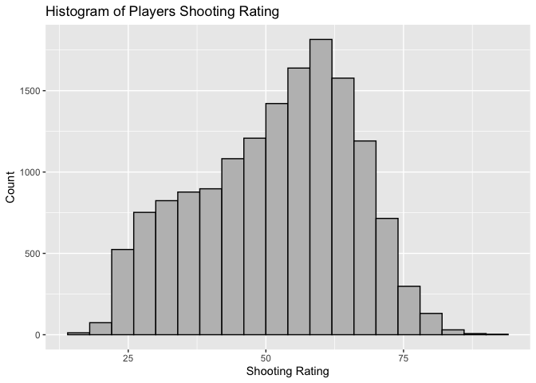

```r
ggplot(data = fifa_data, aes(x = shooting)) +
  geom_histogram(binwidth = 4, color = 'black', fill = 'gray') +
  ggtitle('Histogram of Players Shooting Rating') +
  labs(x = 'Shooting Rating', y = "Count")
```

As we can see from this histogram of players’ shooting rating, the shooting ratings look negatively skewed as it appears there are more players with higher shooting rating than not. The mode of the histogram is around 60-65 shooting rating.

## Plots of X’s vs Y’s

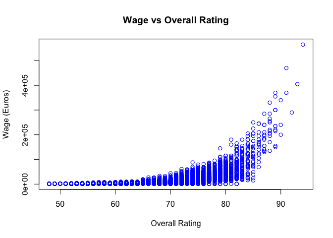

```r
plot(x = fifa_data$overall,
     y = fifa_data$wage_eur,
     ylab = "Wage (Euros)",
     xlab = "Overall Rating",
     main = 'Wage vs Overall Rating',
     col = 'blue')
```

In this plot, you can see that overall rating has a clear correlation with wage. As overall rating goes up, wage also goes up. This plot also looks like an exponential function.

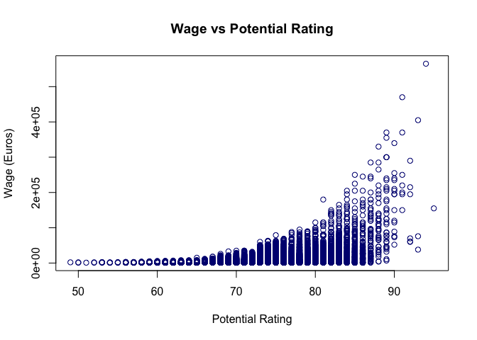

```r
plot(x = fifa_data$potential,
     y = fifa_data$wage_eur,
     ylab = "Wage (Euros)",
     xlab = "Potential Rating",
     main = 'Wage vs Potential Rating',
     col = 'navy')
```

In this plot, you can also see that it is very similar to the results of the overall rating. This is because I think that overall rating is almost the same as potential rating on the players with the highest wages.

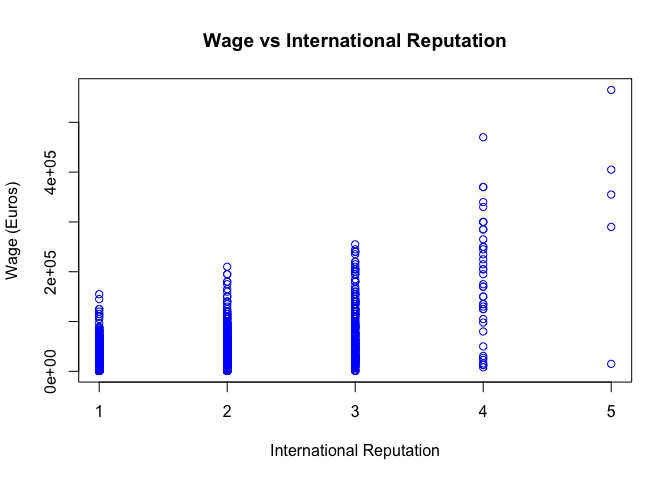

```r
plot(x = fifa_data$international_reputation,
     y = fifa_data$wage_eur,ylab = "Wage (Euros)",
     xlab = "International Reputation",
     main = 'Wage vs International Reputation',
     col = 'blue')
```

Again, this box plot shows that there are many players with an international reputation of 3 or less but, they do not make that much money. Most of the players with an international repuation of 4 or higher earn a much larger salary than those with a rating of 3 or less.

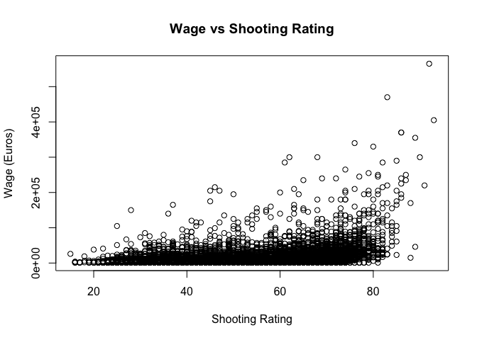

```r
plot(x = fifa_data$shooting, y = fifa_data$wage_eur,
     ylab = "Wage (Euros)",
     xlab = "Shooting Rating",
     main = 'Wage vs Shooting Rating')
```

In this plot, shooting rating does not tell us much about the wage of the players unless their shooting stat is very high compared to other players. As we can see, the players with 90 shooting or above has high salaries compared to 85 and below. I think this is because attackers in soccer are paid more than defenders.

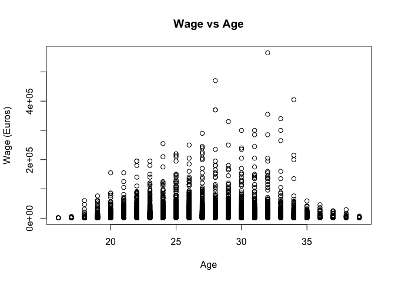

```r
plot(x = fifa_data$age,
     y = fifa_data$wage_eur,
     ylab = "Wage (Euros)",
     xlab = "Age",
     main = 'Wage vs Age')
```

As we can see from this plot, most of the fifa players are between 23 and 33 years old. This is also where the players get paid the most because of their combination of physical form and experience.These are peak years for athletes and they have the wages to back that up.

# Report 2

## Finding the Best Regression

### Regression for different X’s on wage

Model #1

```r
fit_release = lm(data = fifa_data, wage_eur ~ release_clause_eur)
summary(fit_release)$adj.r.squared
```

```
## [1] 0.7286253
```

The variable I chose were players’ release clause in Euros. This variable would make sense because the release clause should be in a similar range to wages.

Model #2

```r
fit_value = lm(data = fifa_data, wage_eur ~ value_eur)
summary(fit_value)$adj.r.squared
```

```
## [1] 0.7341992
```

The variable I chose were players’ value in Euros. This variable would make sense because player value should be in a similar range to wages.

Model #3

```r
fit_pass = lm(data = fifa_data, wage_eur ~ passing)
summary(fit_pass)$adj.r.squared
```

```
## [1] 0.1667702
```

The variable I chose were the players’ passing rating. This variable would make sense because as a player gets better at passing the more a player should get paid.

Model #4

```r
fit_drib = lm(data = fifa_data, wage_eur ~ dribbling)
summary(fit_drib)$adj.r.squared
```

```
## [1] 0.1411672
```

The variable I chose were the players’ dribbling rating. This variable would make sense because as a player gets better at dribbling the more a player should get paid.

Model #5

```r
fit_overall = lm(data = fifa_data, wage_eur ~ overall)
summary(fit_overall)$adj.r.squared
```

```
## [1] 0.340778
```

The variable I chose were the players’ overall rating. This relationahip would make sense because as a player gets better as a player the more they should get paid.

Model #6

```r
fit_potential = lm(data = fifa_data, wage_eur ~ potential)
summary(fit_potential)$adj.r.squared
```

```
## [1] 0.2358599
```

The variable I chose was the potential rating of the players. The relationship between wage and potential rating makes sense because soccer clubs pay for player’s potential.

Model #7

```r
fit_best = lm(wage_eur ~ release_clause_eur +
                value_eur + overall +
                potential, data = fifa_data)
summary(fit_best)$adj.r.squared
```

```
## [1] 0.7382487
```

The variables for this regression were release clause in euros, value in euros, overall rating, and potential rating. The relationship between these variables make sense because all these variables should affect the wage of a player.

### Finding the best fit

```r
summary(fit_best)
```

```
##
## Call:
## lm(formula = wage_eur ~ release_clause_eur + value_eur + overall +
##     potential, data = fifa_data)
##
## Residuals:
##     Min      1Q  Median      3Q     Max
## -159723   -2177    -470    1561  242063
##
## Coefficients:
##                      Estimate Std. Error t value Pr(>|t|)
## (Intercept)         2.836e+03  1.485e+03   1.910   0.0561 .
## release_clause_eur  5.542e-04  7.527e-05   7.363 1.89e-13 ***
## value_eur           2.216e-03  1.460e-04  15.173  < 2e-16 ***
## overall             2.518e+02  1.977e+01  12.738  < 2e-16 ***
## potential          -2.520e+02  2.112e+01 -11.928  < 2e-16 ***
## ---
## Signif. codes:  0 '***' 0.001 '**' 0.01 '*' 0.05 '.' 0.1 ' ' 1
##
## Residual standard error: 11450 on 15072 degrees of freedom
## Multiple R-squared:  0.7383, Adjusted R-squared:  0.7382
## F-statistic: 1.063e+04 on 4 and 15072 DF,  p-value: < 2.2e-16
```

The mean response for release clause was 5.542e-04, mean response for value was 2.216e-03, the mean response for overall rating was 2.518e+02, and the mean response for potential rating was -2.520e+02. This means that holding all other variables constant, an increase of one Euro in release cause will cause wage to increase by .0005542 Euros. An increase of the value of a player by one Euro will cause wage to increase by .002216 Euros. An increase in overall rating will cause an increase in wage by 251.8 Euros. However, an increase in Potential Rating causes the weekly wage to decrease 252 Euros. This makes sense as the better the player, the better the wages. The same thing goes with release clause and value of a player. The more valuable the player, the more the player will get paid. The one weird thing I did notice in the regression was the mean response for potential rating because it was negative. One would think that an increase in potential rating would increase wages but that is simply not the case. One explanation could be that since overall rating and potential rating are very simliar they would cancel each other out in our regression line.

Our F statistic is 1.063e+04 on 4 and 15072 Degrees of Freedom with a p-value of 2.2e-16. This means that our statistics are significant and that our Adjusted R-Squared value is also significant.

## Y vs Yhat

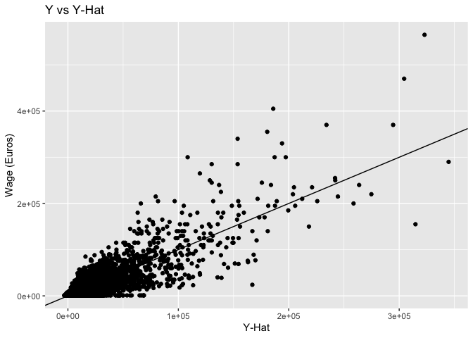

```r
pred = fit_best$fitted.values
ggplot() + geom_point(aes(x = pred, y = fifa_data$wage_eur)) + geom_abline() + ggtitle('Y vs Y-Hat') +
  labs(x = 'Y-Hat', y = 'Wage (Euros)')
```

When plotting Y-hat onto Y, the desired result is a one-to-one relationship. As we can see from the plot, Y is almost a one to one function of the prediction but, the variance of the residuals increases for high values. So we have heteroscedasticity in the wage dimnesion.

## Estimated Coefficients and Standard Error

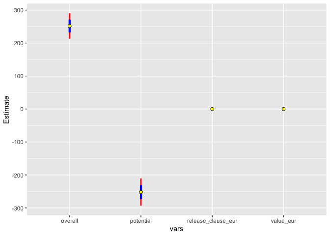

```r
fitBest = summary(fit_best)
coefs = as.data.frame(fitBest$coefficients[-1, 1:2])
names(coefs)[2] = "se"
coefs$vars = rownames(coefs)
ggplot(coefs, aes(vars, Estimate)) +
  geom_errorbar(aes(ymin=Estimate - 1.96*se, ymax=Estimate + 1.96*se), lwd=1,
                colour="red", width=0) +
  geom_errorbar(aes(ymin=Estimate - se, ymax=Estimate + se),
                lwd=1.5, colour="blue", width=0) +
  geom_point(size=2, pch=21, fill="yellow")
```

## Histograms of the Residuals

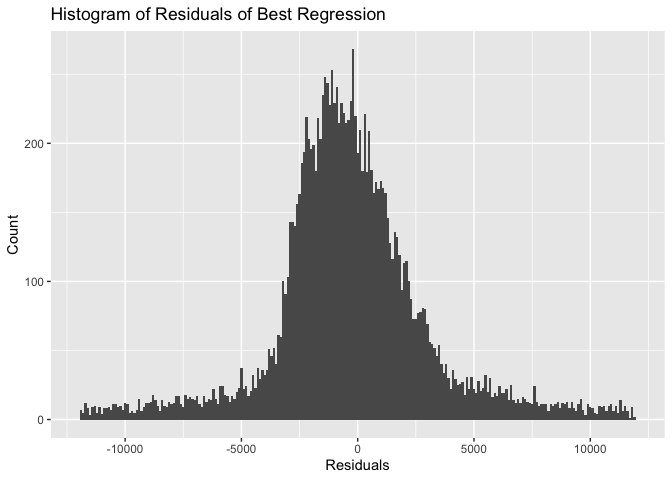

```r
ggplot(data = fifa_data, aes(x = residuals(fit_best))) +
  geom_histogram(binwidth = 100) +
  xlim(-12000,12000) +
  ggtitle('Histogram of Residuals of Best Regression') +
  labs(x = 'Residuals', y = 'Count')
```

[figure not shown]

```r
ggplot() + geom_point(aes(y = fifa_data$wage_eur, x = residuals(fit_best))) +
  ggtitle('Wage vs Residuals of Best Fit') +
  labs(x = 'Wage (Euros)', y = 'Residuals')
```

# Report 3

## Question 1: Creating a train and test subset

```r
set.seed(3)
train = fifa_data %>% sample_frac(.5)
test = fifa_data %>% setdiff(train)
x_train = model.matrix(wage_eur~., train)[,-1]
x_test = model.matrix(wage_eur~., test)[,-1]
y_train = train$wage_eur
y_test = test$wage_eur
```

## Question 2: Creating a Ridge and Lasso Regression

```r
sum(is.na(fifa_data)) # Make sure there are no NA values
```

```
## [1] 0
```

```r
x = model.matrix(wage_eur~., dataOmit)[,-1] # Predictors
y = dataOmit$wage_eur # Y-value
```

```r
grid = 10^seq(10,-2,length = 100)
ridgeMod = glmnet(x, y, alpha = 0, lambda = grid)
dim(coef(ridgeMod))
```

```
## [1]  17 100
```

```r
coef(ridgeMod, s = 50)
```

```
## 17 x 1 sparse Matrix of class "dgCMatrix"
##                                      1
## (Intercept)              -2.111359e+04
## age                       2.701552e+02
## height_cm                 3.047518e+01
## weight_kg                 3.935193e+01
## overall                  -5.065053e+01
## potential                -2.097804e+01
## value_eur                 1.209764e-03
## international_reputation  1.113230e+04
## weak_foot                -2.467164e+01
## skill_moves              -4.572435e+02
## release_clause_eur        8.649789e-04
## pace                      1.034485e+01
## shooting                 -3.480319e+00
## passing                  -3.578219e+01
## dribbling                 7.519871e+01
## defending                 3.598467e+01
## physic                   -4.252524e+01
```

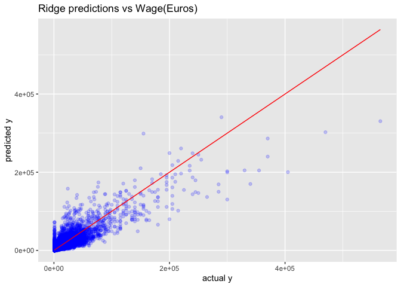

```r
ggplot(data = fifa_data) +
  geom_point(aes(x = wage_eur, y = predict(ridgeMod, s = 50, newx = x)),
             colour = 'blue', alpha = .2) +
  geom_line(aes(x = wage_eur, y = wage_eur),
            colour = 'red') + # plotting Y againts itself produces a red 45 degree line
  ggtitle('Ridge predictions vs Wage(Euros)') +
  xlab('actual y') + ylab('predicted y')
```

```r
ridgeMod = glmnet(x_train, y_train, alpha=0, lambda = grid)
ridgePred = predict(ridgeMod, s = 4, newx = x_test)
mean((ridgePred - y_test)^2)
```

```
## [1] 119596744
```

## Finding Best Lambda

```r
set.seed(3)
cv.out = cv.glmnet(x_train, y_train, alpha = 0)
bestlam = cv.out$lambda.min
bestlam
```

```
## [1] 1906.656
```

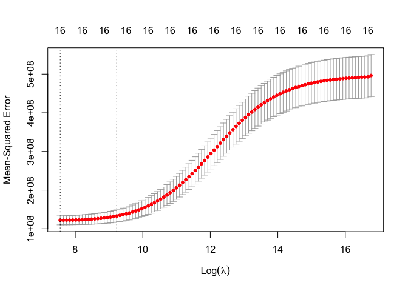

```r
plot(cv.out)
```

```r
ridgePred = predict(ridgeMod, s = bestlam, newx = x_test)
mean((ridgePred - y_test)^2)
```

```
## [1] 119277802
```

```r
out = glmnet(x, y, alpha = 0)
predict(out, type = 'coefficients', s = bestlam)[1:17,]
```

```
##              (Intercept)                      age                height_cm
##            -2.575408e+04             1.772420e+02             2.345209e+01
##                weight_kg                  overall                potential
##             3.145908e+01             7.079869e+01            -3.788361e+00
##                value_eur international_reputation                weak_foot
##             1.304452e-03             1.124138e+04             1.424017e+01
##              skill_moves       release_clause_eur                     pace
##            -2.994581e+02             7.038345e-04             7.569742e+00
##                 shooting                  passing                dribbling
##            -2.168994e+00            -8.055659e+00             3.877976e+01
##                defending                   physic
##             2.581244e+01            -3.041015e+01
```

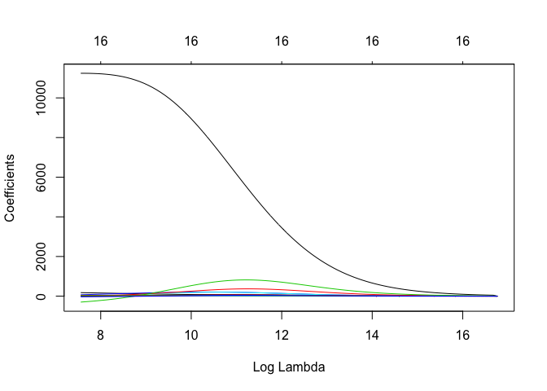

```r
plot(out, xvar = 'lambda')
```

## Lasso

```r
lassoMod = glmnet(x_train, y_train, alpha = 1)
ls(lassoMod)
```

```
##  [1] "a0"        "beta"      "call"      "dev.ratio" "df"        "dim"
##  [7] "jerr"      "lambda"    "nobs"      "npasses"   "nulldev"   "offset"
```

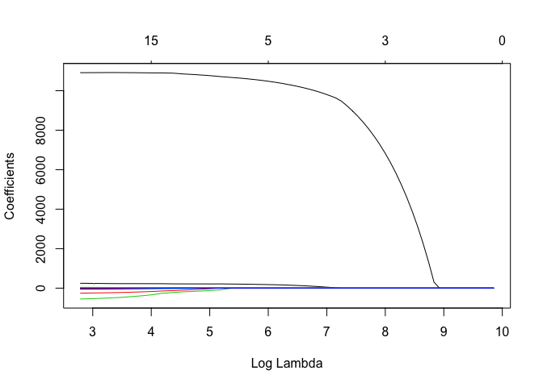

```r
plot(lassoMod, xvar = 'lambda')
```

## Part 3 Regression Tree

### Fit and plot a big tree

```r
set.seed(1)
fifa_train = fifa_data %>% sample_frac(.7)
fifa_test = fifa_data %>% setdiff(fifa_train)
tree_fifa = tree(wage_eur~., fifa_train)
summary(tree_fifa)
```

```
##
## Regression tree:
## tree(formula = wage_eur ~ ., data = fifa_train)
## Variables actually used in tree construction:
## [1] "value_eur"                "overall"
## [3] "international_reputation"
## Number of terminal nodes:  8
## Residual mean deviance:  107600000 = 1.135e+12 / 10550
## Distribution of residuals:
##      Min.   1st Qu.    Median      Mean   3rd Qu.      Max.
## -167500.0   -1649.0    -649.3       0.0    1351.0  172500.0
```

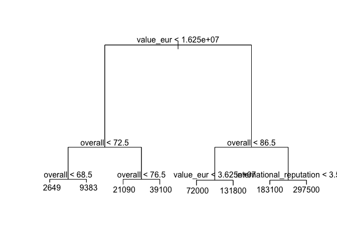

```r
plot(tree_fifa) # The tree
text(tree_fifa, pretty = 2) # The tree
```

```r
single_tree_estimate_tree = predict(tree_fifa, newdata = fifa_test)
mean((single_tree_estimate_tree - fifa_test$wage_eur)^2)
```

```
## [1] 142610192
```

### Check the Error rate or MSE on the test subset

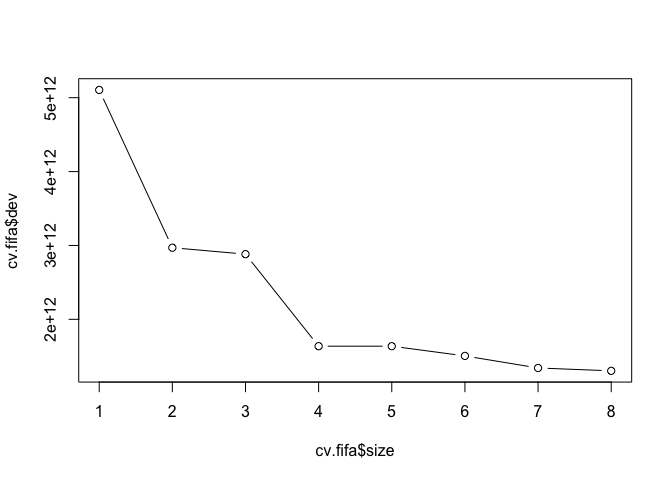

```r
cv.fifa = cv.tree(tree_fifa)
plot(cv.fifa$size, cv.fifa$dev, type = 'b')
```

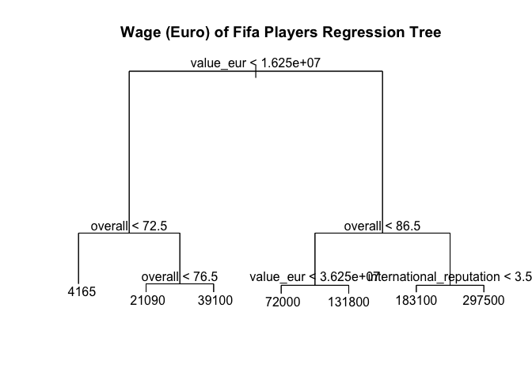

```r
prune_fifa = prune.tree(tree_fifa, best = 7)
plot(prune_fifa)
text(prune_fifa, pretty = 0)
title('Wage (Euro) of Fifa Players Regression Tree')
```

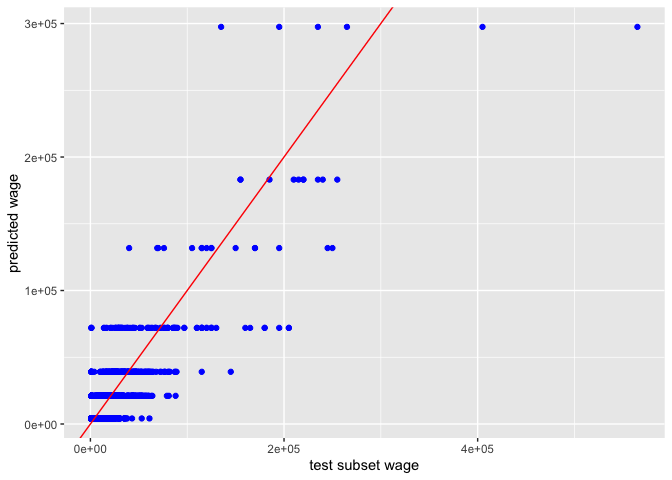

```r
single_tree_estimate_prune = predict(prune_fifa, newdata = fifa_test)
ggplot() +
  geom_point(aes(x = fifa_test$wage_eur, y = single_tree_estimate_prune), color = 'blue') +
  geom_abline(color = 'red') +
  labs(x = 'test subset wage', y = 'predicted wage')
```

```r
mean((single_tree_estimate_prune - fifa_test$wage_eur)^2)
```

```
## [1] 148799466
```

# Conclusion